# 02 - Comparativa de métodos de visión por computador para imágenes pancromáticas (PanchroR vs PanchroB)

Autor/a

Christian Rueda-Ayala

Fecha de publicación

22 de septiembre de 2025

# 1 Introducción

Este informe analiza comparativamente diferentes métodos de visión por computador para alinear y comparar dos imágenes pancromáticas capturadas por sensores distintos (denominados PanchroR y PanchroB), para verificar si las imágenes de ambas cámaras corresponden a la banda Panchromática en cada caso.

La correcta alineación y comparación de imágenes pancromáticas es fundamental en teledetección agrícola, ya que impacta directamente en la calidad de la fusión multiespectral, el cálculo de índices espectrales y la detección de cultivos o especies invasoras.

El objetivo es evaluar qué método de correspondencia de características ofrece mayor precisión y robustez para este tipo de imágenes: **QR + RANSAC**, **SIFT + RANSAC** y **ORB + BFMatcher (Hamming) + RANSAC**.

# 2 Metodología

Se aplican tres métodos de correspondencia de características para imágenes pancromáticas:

- **Método 1: QR + RANSAC**
- **Método 2: SIFT + RANSAC**
- **Método 3: ORB + BFMatcher (Hamming) + RANSAC**

Cada método será evaluado con métricas comunes para determinar cuál ofrece mayor precisión en la alineación.

# 3 Implementación

## 3.1 Documentación de métricas

1. **Porcentaje de coincidencia global** Mide qué porcentaje de píxeles coinciden en ambas imágenes alineadas:
   $${Coin}c_{global} = \frac{Pixeles_{coincidentes}}{Pixeles_{totales}} \times 100$$
2. **IoU (Intersection over Union)** Evalúa el solapamiento entre las máscaras de ambas imágenes:
   $$IoU = \frac{|A \cap B|}{|A \cup B|}$$
3. **Dice Coefficient** Mide la similitud espacial, usado comúnmente en segmentación:
   $$Dice = \frac{2|A \cap B|}{|A| + |B|}$$
4. **RMSE (Root Mean Square Error)** Calcula el error medio cuadrático en la zona coincidente:
   $$RMSE = \sqrt{\frac{1}{N} \sum_{i=1}^{N} (I_1(i) - I_2(i))^2}$$
5. **PSNR (Peak Signal-to-Noise Ratio)** Mide la similitud en intensidad, en decibelios:
   $$PSNR = 20 \cdot \log_{10} \left( \frac{MAX_I}{RMSE} \right)$$

## 3.2 Método 1: QR + RANSAC

Se usan las esquinas detectadas de un código QR como puntos de control. Luego, se calcula la homografía con **RANSAC**:

$$H = \arg\min \sum \rho \left( d(x_i, Hx'_i) \right)$$

donde $\rho$ es la función robusta de RANSAC y $\textbf{\textit{d}}$ es la distancia de reproyección. Con la homografía, se aplica la transformación y se las imágenes.

## 3.3 Método 2: SIFT + RANSAC

El algoritmo **SIFT (Scale Invariant Feature Transform)** detecta y describe puntos clave invariantes a escala y rotación. Luego, **RANSAC** se aplica para estimar la homografía y descartar outliers.  
Se detecta puntos clave con **SIFT**. Luego, se emparejan con **FLANN** y se aplica el test de Lowe:

$$\frac{d(m)}{d(n)} < 0.7$$

Después se estima la homografía con RANSAC y se genera las comparaciones.

## 3.4 Método 3: ORB + BFMatcher (Hamming) + RANSAC

El algoritmo **ORB (Oriented FAST and Rotated BRIEF)** es una alternativa eficiente a SIFT.  
Es computacionalmente más ligero y se combina con un **BFMatcher** que utiliza la distancia de Hamming.  
Finalmente, RANSAC garantiza la estimación robusta de la transformación.  
Se usa **ORB** para extraer descriptores binarios y emparejamos con **BFMatcher** usando distancia de Hamming:

$$d_H(a, b) = \sum_i [a_i \neq b_i]$$

Posteriormente, se estima la homografía con RANSAC y se compara.

# 4 Resultados

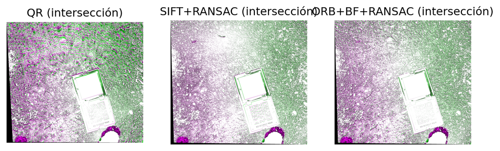

|  | Método | Coincidencia_global_% | IoU | Dice | RMSE | PSNR |
| --- | --- | --- | --- | --- | --- | --- |
| 0 | QR | 39.970984 | 0.998114 | 0.999056 | 12.198318 | 26.404804 |
| 1 | SIFT+RANSAC | 57.055505 | 0.998717 | 0.999358 | 12.160897 | 26.431491 |
| 2 | ORB+BF+RANSAC | 50.603505 | 0.998752 | 0.999376 | 12.072871 | 26.494592 |

Se grafican las métricas obtenidas con cada método.  
Esto permite comparar de forma directa la precisión y robustez de los algoritmos aplicados.

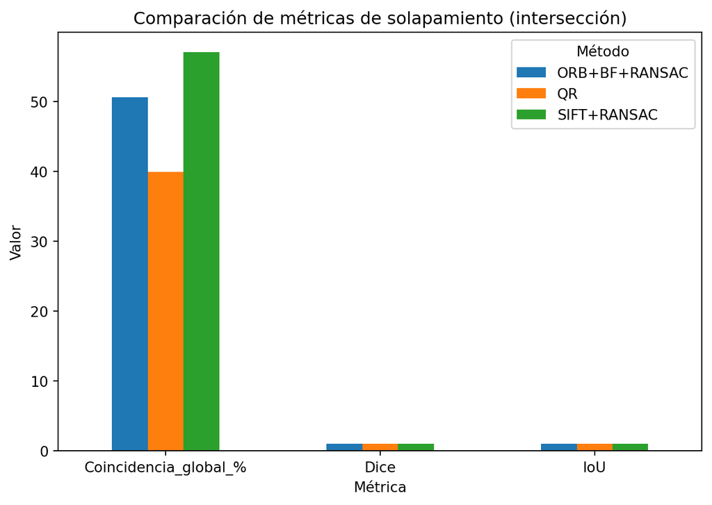

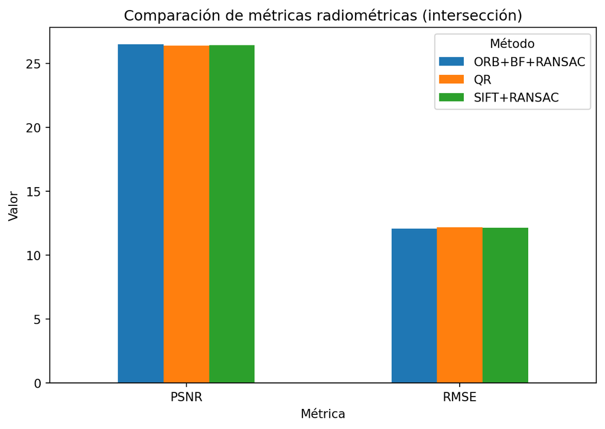

# 5 Discusión

- El método **QR + RANSAC** puede resultar adecuado en escenas bien definidas, aunque su estabilidad es menor frente a ruido y variaciones.
- El método **SIFT + RANSAC** ofrece una mayor robustez y suele ser más fiable para imágenes pancromáticas, aunque requiere más tiempo de cómputo.
- El método **ORB + BFMatcher + RANSAC** se presenta como un balance eficiente, siendo más rápido y con resultados competitivos.

La elección final depende del compromiso entre **precisión** y **eficiencia computacional**.

# 6 Conclusiones